# 4-Modelling

2016-02-25

## Your turn

- What is a model?

## Outline

- Linear Regression

## Real estate prices

```r
library(readr)
realestate <- read_csv("http://dicook.github.io/Monash-R/4-Modelling/data/realestate.csv")
str(realestate)
```

```
#> Classes 'tbl_df', 'tbl' and 'data.frame':    522 obs. of  19 variables:
#>  $ id          : int  1 2 3 4 5 6 7 8 9 10 ...
#>  $ price       : int  360000 340000 250000 205500 275500 248000 229900 150000 195000 160000 ...
#>  $ sqft        : int  3032 2058 1780 1638 2196 1966 2216 1597 1622 1976 ...
#>  $ bed         : int  4 4 4 4 4 4 3 2 3 3 ...
#>  $ bath        : int  4 2 3 2 3 3 2 1 2 3 ...
#>  $ ac          : chr  "yes" "yes" "yes" "yes" ...
#>  $ cars        : int  2 2 2 2 2 5 2 1 2 1 ...
#>  $ pool        : chr  "no" "no" "no" "no" ...
#>  $ built       : int  1972 1976 1980 1963 1968 1972 1972 1955 1975 1918 ...
#>  $ quality     : chr  "medium" "medium" "medium" "medium" ...
#>  $ style       : int  1 1 1 1 7 1 7 1 1 1 ...
#>  $ lot         : int  22221 22912 21345 17342 21786 18902 18639 22112 14321 32358 ...
#>  $ highway     : chr  "no" "no" "no" "no" ...
#>  $ fitted.m3   : num  12.9 12.4 12.2 12.1 12.5 ...
#>  $ fitted.m4   : num  12.7 12.4 12.3 12.2 12.5 ...
#>  $ lot.discrete: chr  "large" "large" "large" "large" ...
#>  $ resid.m5    : num  -0.0212 0.3448 0.0735 0.1227 0.0938 ...
#>  $ fitted.m5   : num  12.8 12.4 12.4 12.1 12.4 ...
#>  $ resid.m5b   : num  -30705 70168 7858 28684 3620 ...
```

## Real estate prices

is a data set consisting of observations on the sales price of 522 homes along with numerous characteristics of the home and property

We might be interested in how the price is affected by these characteristics

## A first model?

- not so fast!
- getting a quick overview of your data using visualizations pays off enormously, because you're not modelling in the dark.

## A generalized scatterplot matrix

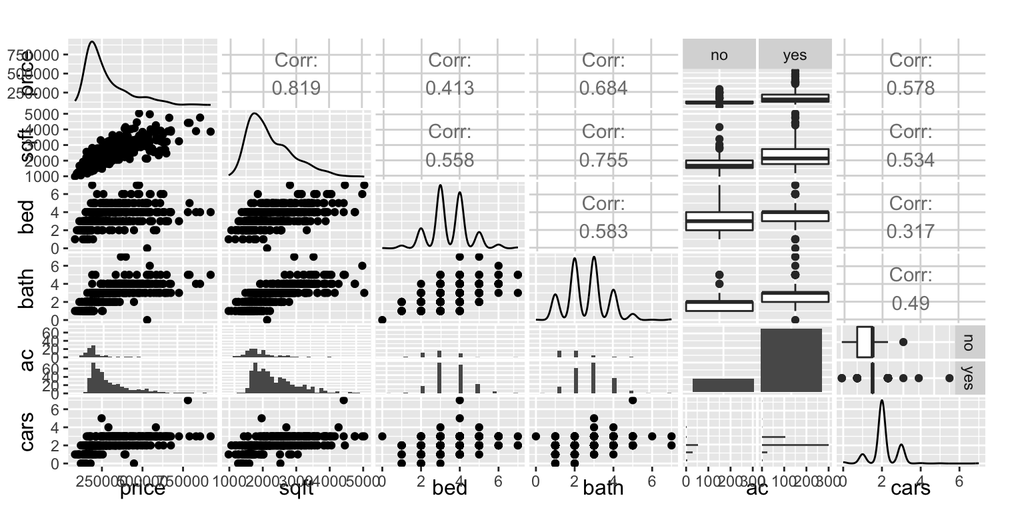

```r
library(GGally)
ggpairs(realestate[,2:7])
```

## Fitting a regression

Fitting a regression model in is accomplished through the `lm` command

```
lm(formula, data, weight, na.action)
```

A formula has the form

`y ~ x1 + x2 + x3`

where `y` is the dependent (price) and `x1, x2, x3` are the covariates

## A first model

```r
lm(price ~ sqft, data=realestate)
```

```
#>
#> Call:
#> lm(formula = price ~ sqft, data = realestate)
#>
#> Coefficients:
#> (Intercept)         sqft
#>      -81433          159
```

Estimate for Intercept is the average price of a 0 sqft home … doesn't make much sense :)

… but, with an increase of the square footage the price increases … that DOES make sense

(1 sq ft = 0.093 sq m or 1 sq m = 10.8 sq ft)

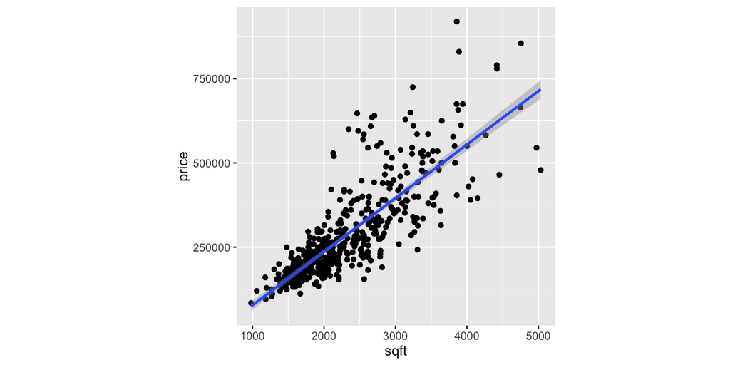

Problem: the variance of the prices increases with the size of the homes.

Solution: use a transformation (square root or log) for the price

Using a log transformation, variability stabilizes (not perfect, but better)

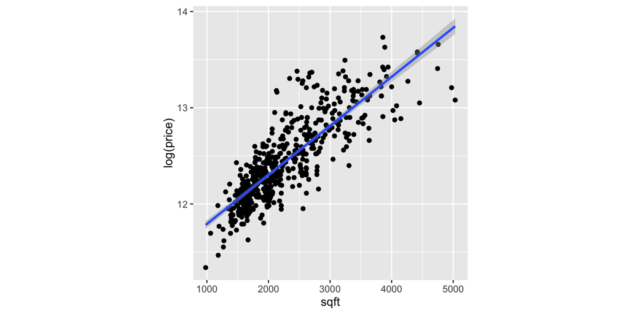

First model then becomes

```r
lm(log(price)~sqft, data=realestate)
```

```
#>
#> Call:
#> lm(formula = log(price) ~ sqft, data = realestate)
#>
#> Coefficients:
#> (Intercept)         sqft
#>   1.128e+01    5.097e-04
```

Models are objects, too (so save model into a named object)

`summary` provides a nicer overview of the model output

```r
m1 <- lm(log(price)~sqft, data=realestate)
summary(m1)
```

```
#>
#> Call:
#> lm(formula = log(price) ~ sqft, data = realestate)
#>
#> Residuals:
#>      Min       1Q   Median       3Q      Max
#> -0.76772 -0.14834 -0.01448  0.11921  0.84182
#>
#> Coefficients:
#>              Estimate Std. Error t value Pr(>|t|)
#> (Intercept) 1.128e+01  3.427e-02  329.24   <2e-16 ***
#> sqft        5.097e-04  1.446e-05   35.24   <2e-16 ***
#> ---
#> Signif. codes:  0 '***' 0.001 '**' 0.01 '*' 0.05 '.' 0.1 ' ' 1
#>
#> Residual standard error: 0.2347 on 520 degrees of freedom
#> Multiple R-squared:  0.7049, Adjusted R-squared:  0.7043
#> F-statistic:  1242 on 1 and 520 DF,  p-value: < 2.2e-16
```

## Adding effects

`update` uses an existing model object and allows for changes of the effects

`.~.+ac` keeps left hand side (. on the left of the ~) the same and adds `ac` to the existing right hand side

```r
m2 <- update(m1, .~.+ac)
```

```r
summary(m2)
```

```
#>
#> Call:
#> lm(formula = log(price) ~ sqft + ac, data = realestate)
#>
#> Residuals:
#>     Min      1Q  Median      3Q     Max
#> -0.7323 -0.1407 -0.0204  0.1180  0.8196
#>
#> Coefficients:
#>              Estimate Std. Error t value Pr(>|t|)
#> (Intercept) 1.120e+01  3.615e-02  309.88  < 2e-16 ***
#> sqft        4.872e-04  1.457e-05   33.45  < 2e-16 ***
#> acyes       1.589e-01  2.764e-02    5.75 1.52e-08 ***
#> ---
#> Signif. codes:  0 '***' 0.001 '**' 0.01 '*' 0.05 '.' 0.1 ' ' 1
#>
#> Residual standard error: 0.2278 on 519 degrees of freedom
#> Multiple R-squared:  0.7226, Adjusted R-squared:  0.7215
#> F-statistic: 675.9 on 2 and 519 DF,  p-value: < 2.2e-16
```

R can deal with categorical and quantitative variables in `lm`

only value for houses with ac (`acyes`) is shown - `acno` is used as baseline, and by default set to 0

```r
options()$contrasts
```

```
#>         unordered           ordered
#> "contr.treatment"      "contr.poly"
```

```r
?contr.treatment
```

## Interpreting Coefficients

!!!Beware transformations!!! they make interpretations tricky sometimes

log of price is expected to be higher by 1.589e-01 for houses with an AC … same as …

price of the house is on average `exp(1.589e-01) = 1.172221` fold higher with AC than the same house without an AC (i.e. AC leads on average to a 17% increase in price)

## Model comparisons

Is model `m2` actually an improvement over `m1` ?

Statistical answer:

```r
anova(m1, m2)
```

```
#> Analysis of Variance Table
#>
#> Model 1: log(price) ~ sqft
#> Model 2: log(price) ~ sqft + ac
#>   Res.Df    RSS Df Sum of Sq      F    Pr(>F)
#> 1    520 28.648
#> 2    519 26.932  1    1.7157 33.063 1.524e-08 ***
#> ---
#> Signif. codes:  0 '***' 0.001 '**' 0.01 '*' 0.05 '.' 0.1 ' ' 1
```

Yes, duh.

## Visually:

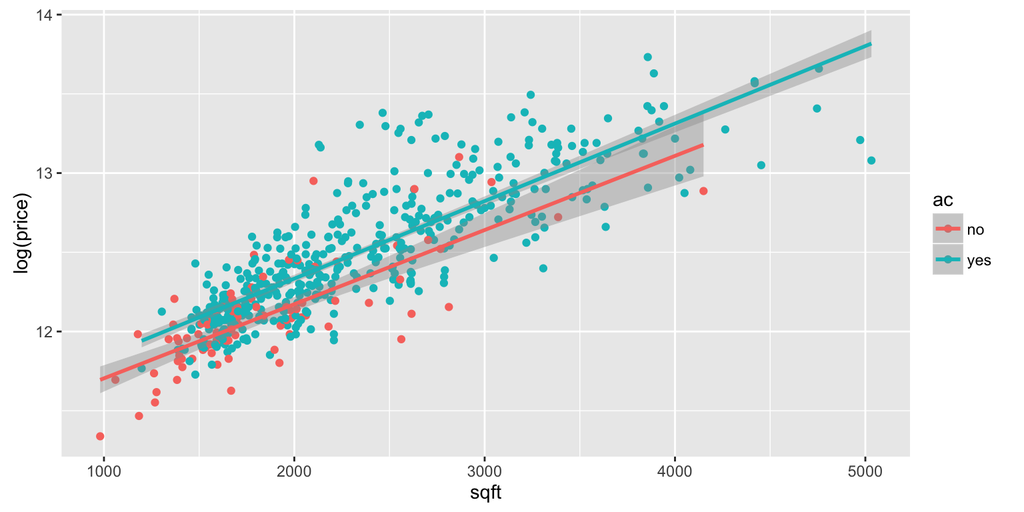

```r
qplot(sqft, log(price), colour=ac, data=realestate) + geom_smooth(method="lm")
```

Yes, but there are not that many houses without AC, so `ac` might not matter terribly much. Visualization gives us a more nuanced answer than the test.

## More effects

Trying to capture the curvature in `log(price)`:

```r
m3 <- lm(log(price) ~ poly(sqft, 2) + ac, data=realestate)
anova(m2, m3)
```

```
#> Analysis of Variance Table
#>
#> Model 1: log(price) ~ sqft + ac
#> Model 2: log(price) ~ poly(sqft, 2) + ac
#>   Res.Df    RSS Df Sum of Sq      F    Pr(>F)
#> 1    519 26.932
#> 2    518 25.274  1    1.6584 33.991 9.751e-09 ***
#> ---
#> Signif. codes:  0 '***' 0.001 '**' 0.01 '*' 0.05 '.' 0.1 ' ' 1
```

## Visualizing models

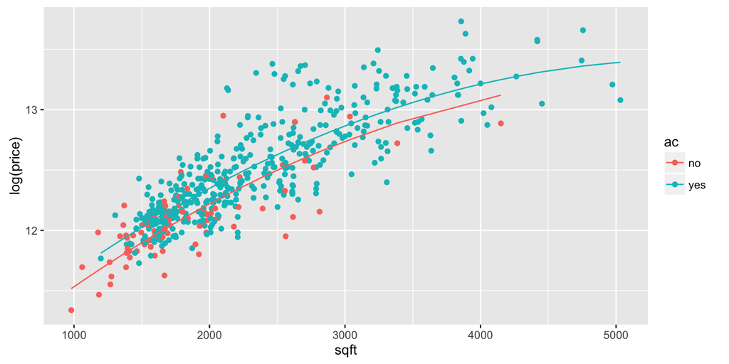

```r
realestate$fitted.m3 <- fitted(m3)
ggplot(data=realestate, aes(y=log(price), x=sqft, colour=ac)) +
  geom_point() +
  geom_line(aes(y=fitted.m3))
```

## Your turn

- Extend model `m3` of the `realestate` data some more and try to find at least two effects that significantly affect prices.
- Visualize the impact those additional effects have on the model

## Specifying Interaction terms

`x:y` specifies the interaction between variables `x` and `y`

`x*y` specifies the main effects `x`, `y` and the interaction

`(a + b + c)^2` specifies all main effects and pairwise interactions

`(a + b + c)^2 - b:c` specifies all main effects and pairwise interactions, but not the b-c interaction

`-1` removes the term for the intercept

## Making Predictions

Suppose we have model

```r
m5 <- lm(log(price) ~ sqft + bath + built + log(lot), data = realestate)
```

> Suppose a new house is going on the market and the seller wants to use this model to get an idea of a reasonable listing price. This house is 2123 sq. ft. with 4 bedrooms, 2 bathrooms, a 20590 sq. ft. lot, and was built in 1963.

```r
new_house <- data.frame(sqft = 2123, bath = 2, built = 1963, lot = 20590)

predict(m5, newdata = new_house, interval = "prediction", level = 0.95) # log(price)!
```

```
#>        fit     lwr      upr
#> 1 12.31436 11.9268 12.70192
```

```r
exp(predict(m5, newdata = new_house, interval = "prediction", level = 0.95))/1000
```

```
#>        fit      lwr      upr
#> 1 222.8737 151.2661 328.3794
```

## Model Diagnostics

## Assumptions of a (normal) linear model

Using linear regression models we inherently make the following assumptions:

- Normally distributed errors
- Constant error variance
- Linearity in the parameters
- Independent (uncorrelated) errors

Also generally want to check for collinearity and influential points

## Assessing normality of residuals

We can assess the assumption of normality using a normal probability plot of residuals (sometimes called a normal `qq` plot)

Idea of normal qq plot:

- Plot the empirical cdf of the errors against the theoretical quantiles of a normal distribution
- If errors are normal empirical and theoretical quantiles will be proportional
- Look for a straight line relationship in the plot

```r
m5 <- lm(log(price) ~ sqft + bath + built + log(lot), data = realestate)
```

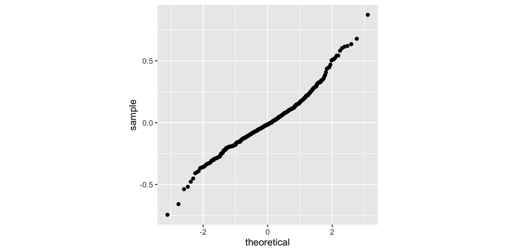

```r
realestate$resid.m5 <- residuals(m5)
realestate$fitted.m5 <- fitted(m5)
ggplot(aes(sample = resid.m5), data=realestate) + geom_qq() + theme(aspect.ratio=1)
```

The wavy pattern indicates a slightly heavy tail in the residuals.

## Unlogged price is worse deviation from normality

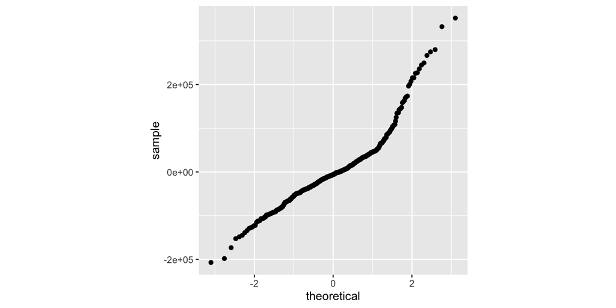

```r
m5b <- lm(price ~ sqft + bath + built + log(lot), data = realestate)

realestate$resid.m5b <- residuals(m5b)
ggplot(aes(sample = resid.m5b), data=realestate) + geom_qq() + theme(aspect.ratio=1)
```

## Equal variance and linearity

We can assess the assumptions of equal error variance and linearity using residual plots

Idea of checking residual plots:

- plot model residuals against predicted values in scatterplot
- (linearity) points should show no distinct shape or clustering
- (equal variance) scatter of points should not widen or constrict over range of predicted values

## Residual plots

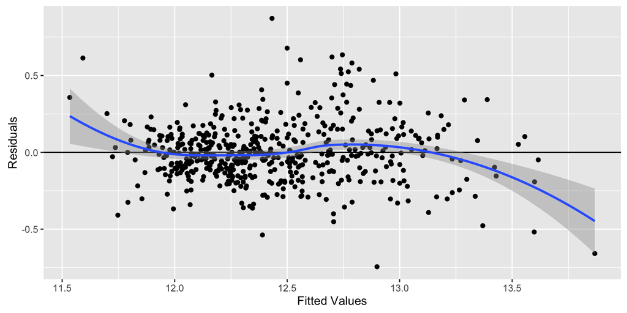

```r
qplot(data=realestate, x=fitted.m5, y=resid.m5) + xlab("Fitted Values") + ylab("Residuals") +
  geom_hline(yintercept=0) + geom_smooth()
```

## Your turn

- Use unlogged price in a linear model and draw the residual plot. What do you find?

## Test for Equal Error variance

Many R packages available to do specific statistical diagnostics tests `lmtest` package contains many of these tests, such as a Breusch-Pagan test for equal variances

```r
library(lmtest)
bptest(m5)
```

```
#>
#>  studentized Breusch-Pagan test
#>
#> data:  m5
#> BP = 28.123, df = 4, p-value = 1.178e-05
```

… so there's still heteroskedasticity in those errors … darn!

## Box-Cox transformations

Box Cox method for transformations selects a data transform based on the relationship between the observed mean and variance

\[ y_i^{(\lambda)} = \begin{cases} \dfrac{y_i^\lambda - 1}{\lambda} & \text{if } \lambda \neq 0, \\[8pt] \ln{(y_i)} & \text{if } \lambda = 0, \end{cases} \]

Use `boxcox()` function from the `MASS` package to ballpark a \(\lambda\)

```r
library(MASS)
bc <- boxcox(m5b)
```

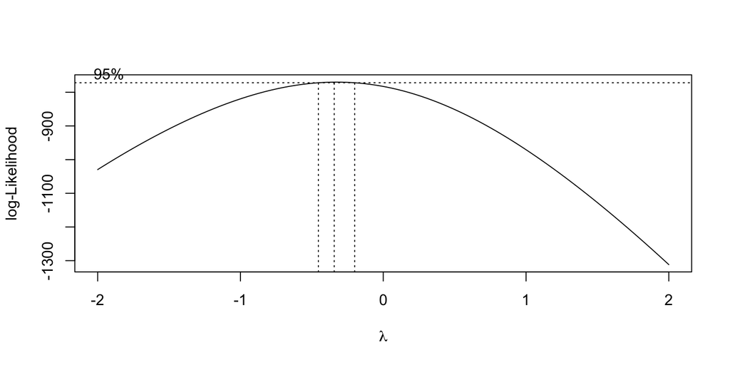

```r
str(bc)
```

```
#> List of 2
#>  $ x: num [1:100] -2 -1.96 -1.92 -1.88 -1.84 ...
#>  $ y: num [1:100] -1030 -1019 -1008 -998 -988 ...
```

```r
lambda <- bc$x[which.max(bc$y)]
```

Now re-fit model with transformed price …

```r
m5c <- lm(price^lambda ~ sqft + bath + built + log(lot), data=realestate)
bptest(m5c) # better but still not non-significant
```

```
#>
#>  studentized Breusch-Pagan test
#>
#> data:  m5c
#> BP = 14.856, df = 4, p-value = 0.00501
```

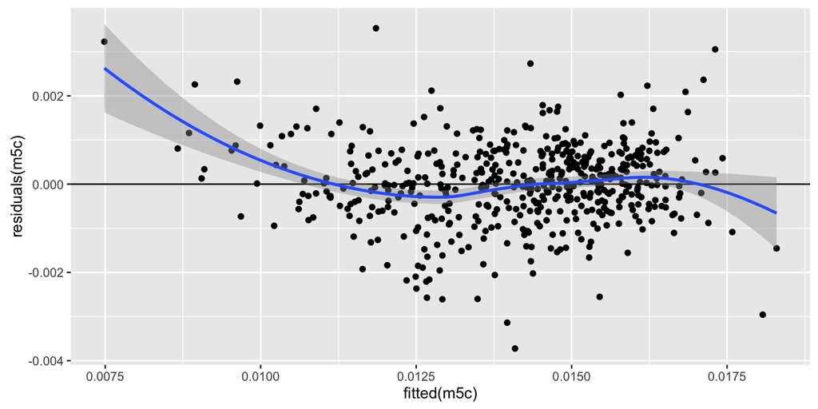

```r
qplot(fitted(m5c), residuals(m5c)) + geom_hline(yintercept=0) + geom_smooth()
```

Interpretation of model coefficients has become even more tricky …

## Other model diagnostics

- on the model level: AIC, BIC, \(R^2\), adjusted \(R^2\), …
- on the coefficient level: VIF (Variance Inflation Factors), …
- on the point level:
  - High leverage (more potential to be influential)
  - DFFITS (too much influence on its own fitted value)
  - Cook’s D (too much influence on all fitted values)
  - DFBETAS (too much influence on estimated parameters)

R can calculate every single one of them … and more …

## Working with lots of models

## Why would we even do that???

- Hans Rosling can explain that really well in his [TED talk](https://www.ted.com/talks/hans_rosling_shows_the_best_stats_you_ve_ever_seen?language=en)
- gapminder software
- gapminder also makes data available (in R through the package `gapminder`)

## First Look

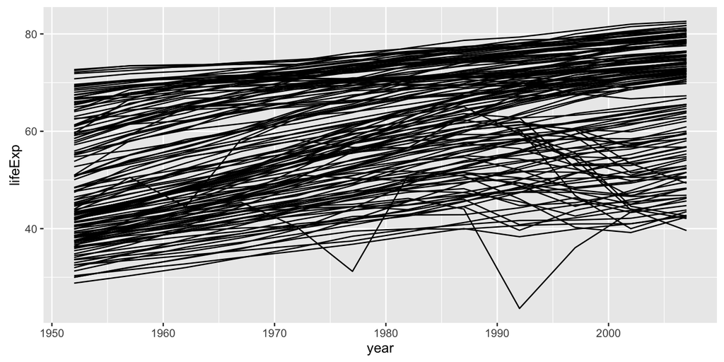

```r
library(gapminder)
qplot(data=gapminder, year, lifeExp, geom="line", group=country)
```

How would you describe this plot?

## Using models as exploratory tools

- Idea: fit a line to each one of the countries' life expectancies
- then use e.g. intercept and slope to characterise groups of countries

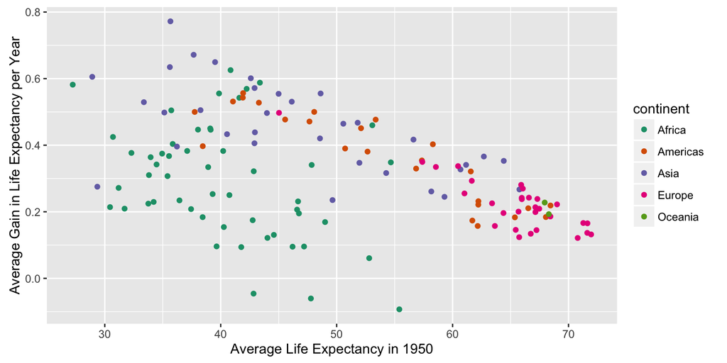

## Prepping

- This is hot off the press (presented by Hadley Wickham last week at WOMBAT)
- you might have to re-install the packages `tidyr` and `purrr`, i.e. run the following code:

```r
install.packages("tidyr")
install.packages("purrr")

library(tidyr)
library(purrr)
```

## Australian Life Expectancy

```r
oz <- subset(gapminder, country=="Australia")
head(oz)
```

```
#> Source: local data frame [6 x 6]
#>
#>     country continent  year lifeExp      pop gdpPercap
#>      (fctr)    (fctr) (int)   (dbl)    (int)     (dbl)
#> 1 Australia   Oceania  1952   69.12  8691212  10039.60
#> 2 Australia   Oceania  1957   70.33  9712569  10949.65
#> 3 Australia   Oceania  1962   70.93 10794968  12217.23
#> 4 Australia   Oceania  1967   71.10 11872264  14526.12
#> 5 Australia   Oceania  1972   71.93 13177000  16788.63
#> 6 Australia   Oceania  1977   73.49 14074100  18334.20
```

## Life Expectancy in Australia since 1950

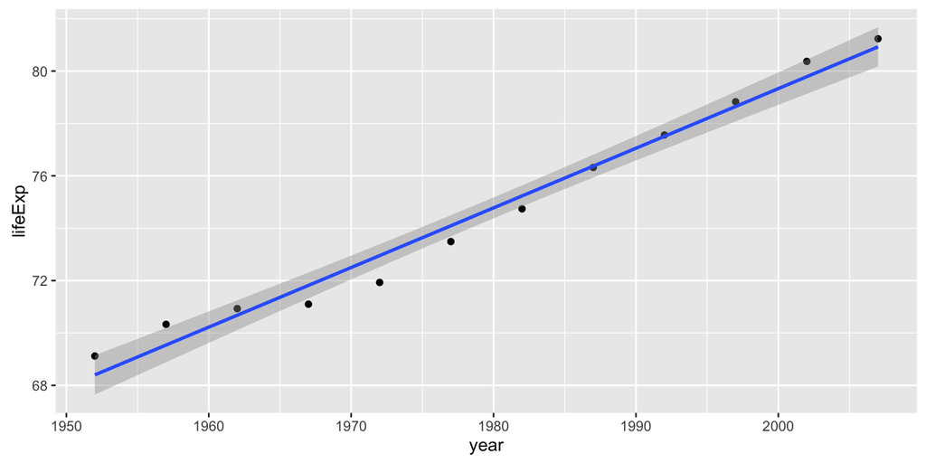

```r
qplot(data=oz, year, lifeExp) + geom_smooth(method="lm")
```

## Life Expectancy in Australia since 1950

```r
oz.lm <- lm(lifeExp~year, data=oz)
oz.lm
```

```
#>
#> Call:
#> lm(formula = lifeExp ~ year, data = oz)
#>
#> Coefficients:
#> (Intercept)         year
#>   -376.1163       0.2277
```

Intercept is estimated life expectancy at 0 BC - let's use 1950 for the first value:

```r
gapminder <- gapminder %>% mutate(year = year-1950)
```

## Nesting data

We don't want to subset the data for every country …

`nest()` makes a data frame part of another data frame:

```r
by_country <- gapminder %>% group_by(continent, country) %>% nest()
head(by_country)
```

```
#> Source: local data frame [6 x 3]
#>
#>   continent     country            data
#>      (fctr)      (fctr)           (chr)
#> 1      Asia Afghanistan <tbl_df [12,4]>
#> 2    Europe     Albania <tbl_df [12,4]>
#> 3    Africa     Algeria <tbl_df [12,4]>
#> 4    Africa      Angola <tbl_df [12,4]>
#> 5  Americas   Argentina <tbl_df [12,4]>
#> 6   Oceania   Australia <tbl_df [12,4]>
```

Each element of the `data` variable in `by_country` is a dataset:

```r
head(by_country$data[[1]])
```

```
#> Source: local data frame [6 x 4]
#>
#>    year lifeExp      pop gdpPercap
#>   (dbl)   (dbl)    (int)     (dbl)
#> 1     2  28.801  8425333  779.4453
#> 2     7  30.332  9240934  820.8530
#> 3    12  31.997 10267083  853.1007
#> 4    17  34.020 11537966  836.1971
#> 5    22  36.088 13079460  739.9811
#> 6    27  38.438 14880372  786.1134
```

```r
lm(lifeExp~year, data=by_country$data[[1]])
```

```
#>
#> Call:
#> lm(formula = lifeExp ~ year, data = by_country$data[[1]])
#>
#> Coefficients:
#> (Intercept)         year
#>     29.3566       0.2753
```

## Fitting multiple models

Now we are using the `map` function in the package `purrr`.

`map` allows us to apply a function to each element of a list.

```r
by_country$model <- by_country$data %>% purrr::map(~lm(lifeExp~year, data=.))
head(by_country)
```

```
#> Source: local data frame [6 x 4]
#>
#>   continent     country            data   model
#>      (fctr)      (fctr)           (chr)   (chr)
#> 1      Asia Afghanistan <tbl_df [12,4]> <S3:lm>
#> 2    Europe     Albania <tbl_df [12,4]> <S3:lm>
#> 3    Africa     Algeria <tbl_df [12,4]> <S3:lm>
#> 4    Africa      Angola <tbl_df [12,4]> <S3:lm>
#> 5  Americas   Argentina <tbl_df [12,4]> <S3:lm>
#> 6   Oceania   Australia <tbl_df [12,4]> <S3:lm>
```

## On to the `broom` package

`broom` allows to extract values from models on three levels:

- for each model: `broom::glance`
- for each coefficient in the model: `broom::tidy`
- for each value in the dataset: `broom::augment`

```r
library(broom)
broom::glance(by_country$model[[1]])
```

```
#>   r.squared adj.r.squared    sigma statistic      p.value df    logLik
#> 1 0.9477123     0.9424835 1.222788  181.2494 9.835213e-08  2 -18.34693
#>        AIC      BIC deviance df.residual
#> 1 42.69387 44.14859  14.9521          10
```

```r
broom::tidy(by_country$model[[1]])
```

```
#>          term   estimate  std.error statistic      p.value
#> 1 (Intercept) 29.3566375 0.69898128  41.99918 1.404235e-12
#> 2        year  0.2753287 0.02045093  13.46289 9.835213e-08
```

```r
broom::augment(by_country$model[[1]])
```

```
#>    lifeExp year  .fitted   .se.fit      .resid       .hat   .sigma
#> 1   28.801    2 29.90729 0.6639995 -1.10629487 0.29487179 1.211813
#> 2   30.332    7 31.28394 0.5799442 -0.95193823 0.22494172 1.237512
#> 3   31.997   12 32.66058 0.5026799 -0.66358159 0.16899767 1.265886
#> 4   34.020   17 34.03722 0.4358337 -0.01722494 0.12703963 1.288917
#> 5   36.088   22 35.41387 0.3848726  0.67413170 0.09906760 1.267003
#> 6   38.438   27 36.79051 0.3566719  1.64748834 0.08508159 1.154002
#> 7   39.854   32 38.16716 0.3566719  1.68684499 0.08508159 1.147076
#> 8   40.822   37 39.54380 0.3848726  1.27820163 0.09906760 1.208243
#> 9   41.674   42 40.92044 0.4358337  0.75355828 0.12703963 1.260583
#> 10  41.763   47 42.29709 0.5026799 -0.53408508 0.16899767 1.274051
#> 11  42.129   52 43.67373 0.5799442 -1.54472844 0.22494172 1.148593
#> 12  43.828   57 45.05037 0.6639995 -1.22237179 0.29487179 1.194109
#>         .cooksd  .std.resid
#> 1  2.427205e-01 -1.07742164
#> 2  1.134714e-01 -0.88428127
#> 3  3.603567e-02 -0.59530844
#> 4  1.653992e-05 -0.01507681
#> 5  1.854831e-02  0.58082792
#> 6  9.225358e-02  1.40857509
#> 7  9.671389e-02  1.44222437
#> 8  6.668277e-02  1.10129103
#> 9  3.165567e-02  0.65958143
#> 10 2.334344e-02 -0.47913530
#> 11 2.987950e-01 -1.43494020
#> 12 2.963271e-01 -1.19046907
```

## Extract values for each coefficient

Extract all countries automatically (hello `map` again!)

```r
by_country_coefs <- by_country %>% unnest(model %>% purrr::map(broom::tidy))
coefs <- by_country_coefs %>% select(country, continent, term, estimate) %>% spread(term, estimate)
```

and finally, a visualization:

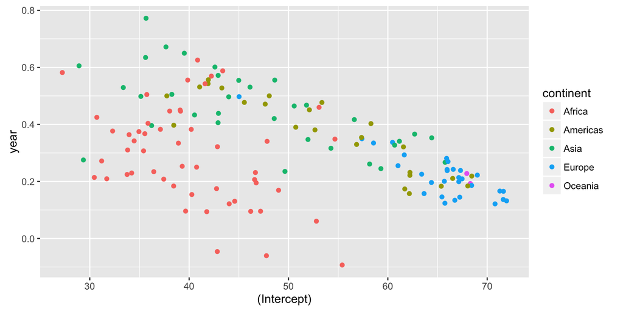

```r
qplot(`(Intercept)`, year, colour=continent, data=coefs)
```

## Extract other model diagnostics

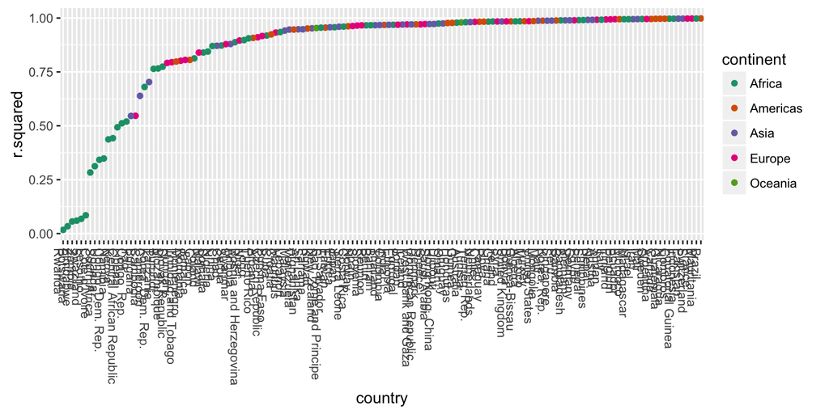

```r
by_country <- by_country %>% unnest(model %>% purrr::map(broom::glance))
by_country$country <- reorder(by_country$country, by_country$r.squared)
qplot(country, r.squared, colour=continent, data=by_country) +
  theme(axis.text.x=element_text(angle=-90, hjust=0)) +
  scale_colour_brewer(palette="Dark2")
```

## Compare groups of countries

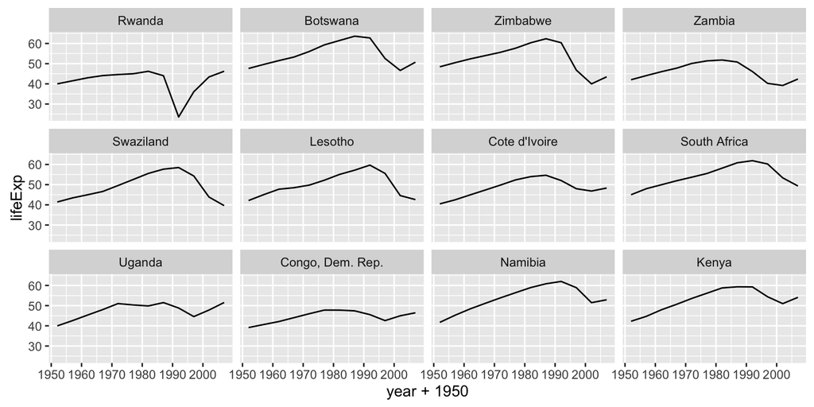

```r
country_all <- by_country %>% unnest(data)
qplot(year+1950, lifeExp,  data=subset(country_all, r.squared <= 0.45), geom="line") +
  facet_wrap(~country)
```

What do the patterns mean?

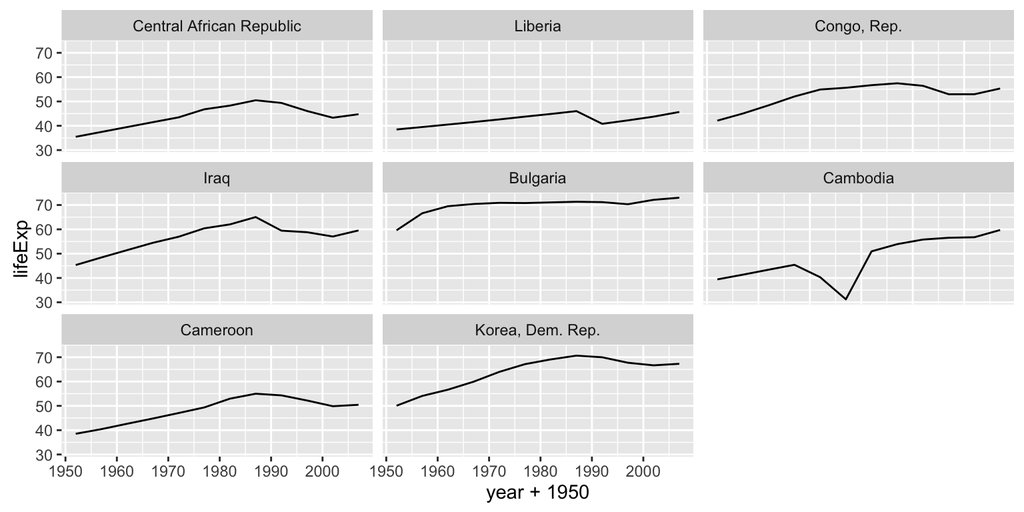

```r
qplot(year+1950, lifeExp,  data=subset(country_all, between(r.squared, 0.45, 0.75)), geom="line") +
  facet_wrap(~country)
```

## Your turn

- extract residuals for each of the models and store it in a dataset together with country and continent information
- plot residuals across the years and fit a smooth. What does the pattern mean?

## Share and share alike

This work is licensed under the Creative Commons Attribution-Noncommercial 3.0 United States License. To view a copy of this license, visit http://creativecommons.org/licenses/by-nc/ 3.0/us/ or send a letter to Creative Commons, 171 Second Street, Suite 300, San Francisco, California, 94105, USA.